# Introduction to R

# Advanced Graphics with ggplot

## Advanced graphics in R

- R has several advanced graphics packages such as `ggplot2` (see [book](https://ggplot2-book.org/) by Hadley Wickham), `plotly`, `Rgnuplot`,…
- We will focus on ggplot2 as this is widely used.
- The ggplot2 package in R enables to build complex plots from data in a structured and layered manner.
- The plot is based on a specified data frame, aesthetic mappings (like x and y axes), and layers such as points, lines, or bars (geom_* functions).
- Advantages: flexible, consistent syntax, and fancy graphics.
- Disadvantages: Very different syntax e.g. compared to functions.

## Typical ggplot help function sections

- Section What it Gives You
- Title Short description
- Description What the function does
- Usage The function’s syntax
- Arguments What each argument means
- Details Extra explanation and special behavior
- Aesthetics Visual mappings (like x, y, color, etc.)
- Examples Example code to learn from

```r
?ggplot2::geom_line
```

## Using ggplot: Grammar of graphics

- Graphics with ggplot2 are built step-by-step, adding new elements as layers
- A plot starts with the function ggplot(). This is the main object we will add layers to.
- Each layer is added with a plus sign (+) between layers. This allows for extensive flexibility and customization of plots.
- Three components need to be specified for the plot:
  - data: data to feed in
  - aesthetics: how you will connect variables (columns) from your data to a visual dimension. Horizontal positioning, size, color etc.
  - geometries: This is a specification of what object will actually be drawn on the plot. This could be a point, a line, a bar, etc.

## Using ggplot: Grammar of graphics (cont’d)

- Several optional additional layers customize the graphics and help make flexible graphs.
  - Scales: How a variable is mapped to its aesthetic. Can be linear, in log scale etc.
  - Statistical transformations: Specification of whether and how the data are combined/transformed before being plotted.
  - Coordinate system: Specification of how the position aesthetics (x and y) are depicted, for example cartesian or polar coordinates.
  - Facet: This is a specification of data variables that partition the data into smaller “sub plots”, or panels.

## Example ggplot (cont’d)

- Help files of ggplot2 are also slightly different from the standard R help files

```r
?ggplot # a bit complicated help file
help(package = "ggplot2") # a nicer list of all layer functions, see 'geom_line'
```

## Example: Histogram of temperatures in Maastricht

- Notice the syntax difference in parentheses and use of `+` for layers
- Notice the data `wide_data` is a data frame with an index

```r
library('ggplot2')
load("data/climate_wide.Rdata") # load data
wide_data$index <- 1:nrow(wide_data) # create data frame
ggplot(wide_data, aes(x = MAASTRICHT)) +
  geom_histogram(bandwidth = 200)
```

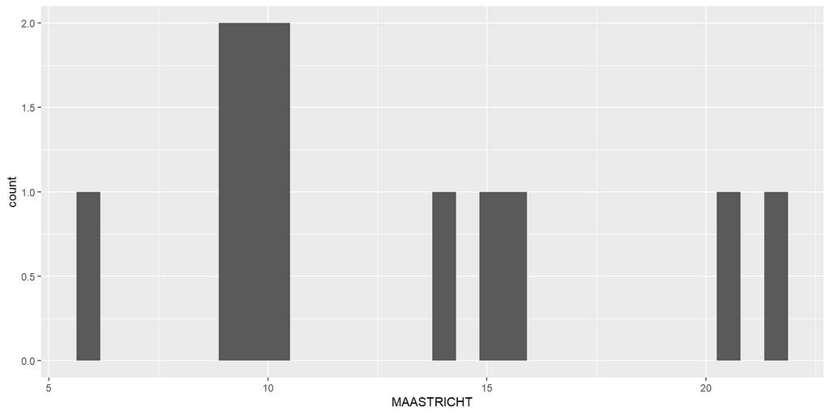

## Example: Plot of temperatures in Maastricht

- We will make a similar plot to exercise 4.4: a plot of temperatures in Maastricht
- Aesthetics are defined with line width, color.
- Geometrics is defined by the function `geom_line` (line plot)

```r
load("data/climate_wide.Rdata") # load data
wide_data$index <- 1:nrow(wide_data) # create data frame
ggplot(wide_data, aes(x = index, y = MAASTRICHT)) +
  geom_line(color = "blue", linewidth = 1) # adds lines #
```

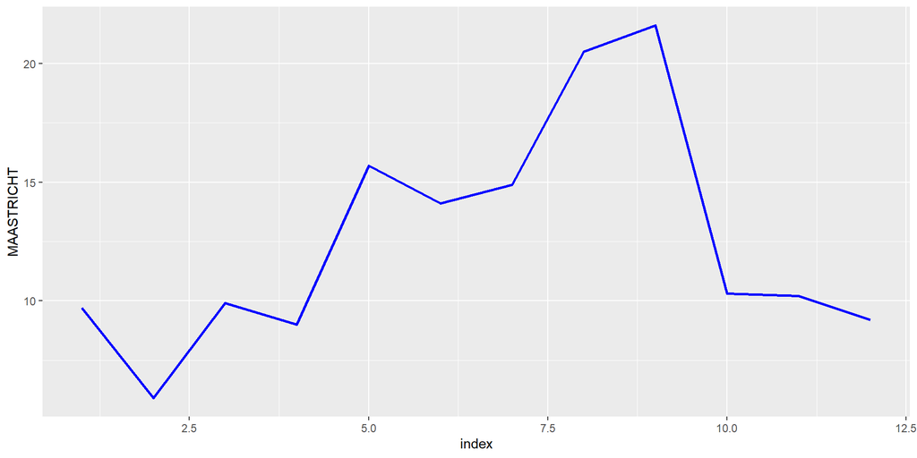

## Example: Possible confusion with aesthetics

```r
load("data/climate_wide.Rdata") # load data
wide_data$index <- 1:nrow(wide_data) # create data frame
ggplot(wide_data, aes(x = index, y = MAASTRICHT, color = "blue")) +
  geom_line(linewidth = 1) # adds lines #
```

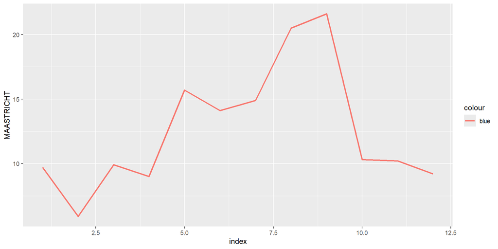

## Example: Adding additional geometrics and aesthetics

```r
load("data/climate_wide.Rdata") # load data
wide_data$index <- 1:nrow(wide_data) # create data frame
ggplot(wide_data, aes(x = index, y = MAASTRICHT)) +
  geom_line(color = "blue", size = 1, linewidth = 2) +
  geom_line(aes(x = index, y = EINDHOVEN), linewidth = 0.3) # Adds Eindhoven data to the last plot
```

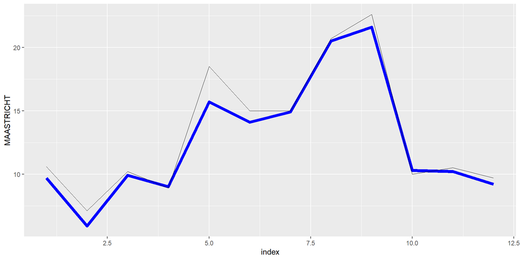

## Example: Adding more layers

- Adding more layers for labels and legends

```r
load("data/climate_wide.Rdata") # load data
wide_data$index <- 1:nrow(wide_data) # create data frame
ggplot(wide_data, aes(x = index, y = MAASTRICHT)) +
  geom_line(color = "blue", size = 1, linewidth = 2) +
  geom_line(aes(x = index, y = EINDHOVEN), linewidth = 0.3) + # Adds Eindhoven data to the last plot
  labs(
    x = "X Axis", y = "Y Axis", color = "Legend Title",   # Axis labels and legend title
    title = "Line Plot with Two Variables"
  ) +
  scale_color_manual(values = c("blue", "red")) +  # Custom colors
  theme_minimal()  # Minimal theme for a clean look
```

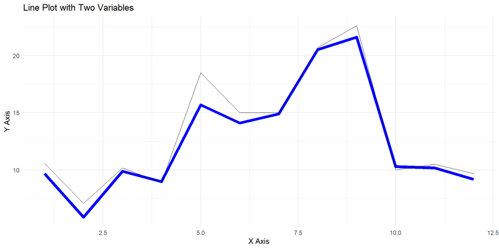

## Example ggplot: Color points for Maastricht and Eindhoven temperatures

- For this example, we will use the long dataframe since we will plot values for both cities.
- This is a more complex graph where aesthetics defined in geometrics create point colors according to a variable in the data frame.

```r
library('ggplot2')
load("data/climate_long.Rdata") # load data
long_data$index <- 1:nrow(long_data) # create data frame
ggplot(data = long_data) +
  geom_point(aes(x = index, y = TEMP, color = NAME))
```

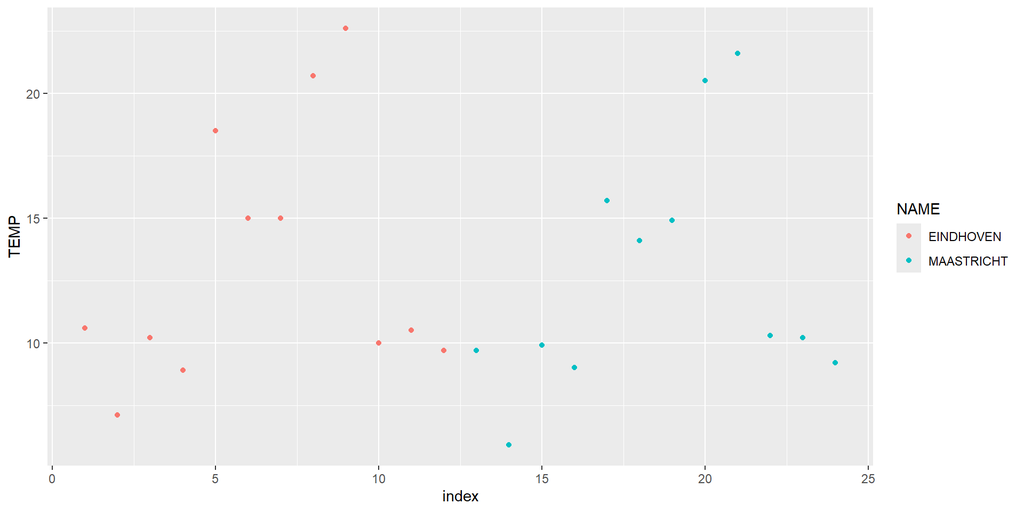

## Further references for ggplot2

- [R for data science](https://nt246.github.io/NTRES-6100-data-science/lesson6-ggplot-part1.html#Preparing_to_create_our_first_ggplot2_graph)
- [Collaborative and Reproducible Data Science in R](https://nt246.github.io/NTRES-6100-data-science/lesson6-ggplot-part1.html#Preparing_to_create_our_first_ggplot2_graph)

## Exercise 4.6: Use ggplot2 for more flexible and advanced plots

- Make the same plot as in Exercise 4.4 using package `ggplot2’
- We suggest to use the wide data
- Use help functions for `geom_point`, `geom_hline`, `labs`.
- You can give it a try to use ChatGPT, but the outcome is difficult to understand if you don’t have familiarity with ggplot to begin with.